# A Comparison of High-Dose and Regular-Dose Seasonal Influenza Vaccines Toward Eliciting Homologous and Heterologous Immunity

2021-04-27 13:05:20

## Introduction

- Antigen dose is an important determinant of vaccines.
- A universal flu vaccine needs to induce strong and broad responses. Dose likely impacts both strength and breadth.
- For influenza, there is currently a high-dose (HD) vaccine approved for those >=65 years of age.
- HD has been shown to induce higher immunogenicity and protection against vaccine strains.
- Impact of dose on heterologous responses is uncertain.

## Goals

- **Long-term:** Better understand and optimize dose toward inducing strong and broad immune protection.
- **Short-term:** Detailed analysis of strength and breadth of immune response following vaccination with high-dose (HD) versus standard dose (SD) influenza Fluzone vaccine.

## Data

- Open cohort of individuals who were vaccinated during the 2014/15 - 2018/19 flu seasons.
- The default vaccine was the trivalent or quadrivalent standard dose (SD, 15µg) Fluzone vaccine.
- Individuals >=65 were offered the high-dose (HD, 60µg) trivalent Fluzone vaccine.
- Analysis of immune response (HAI) for SD vs. HD individuals.
- Focus on individuals >=65 years, only look at B-strains that are in both SD and HD.

## Study population

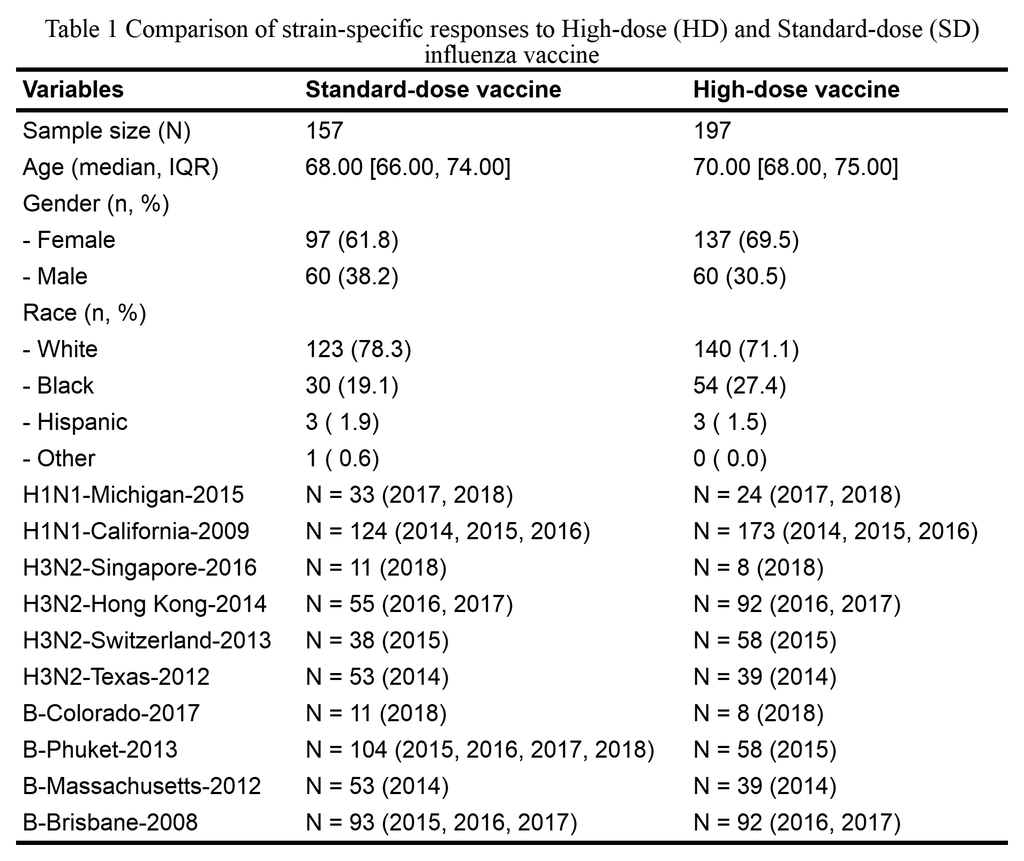

## The data

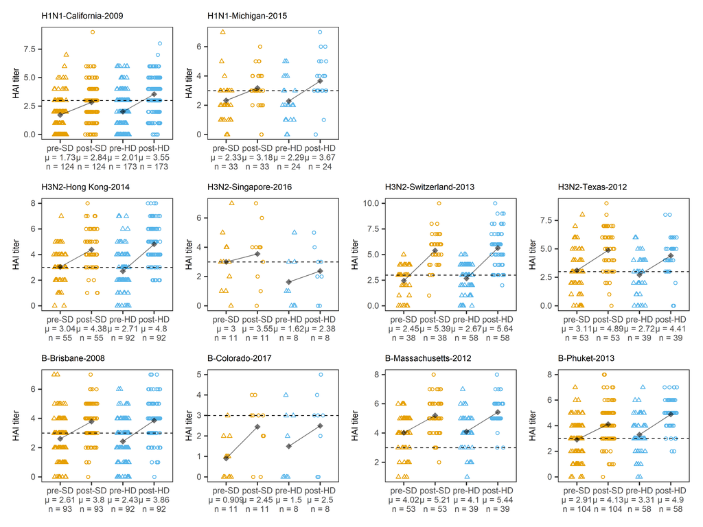

## The data

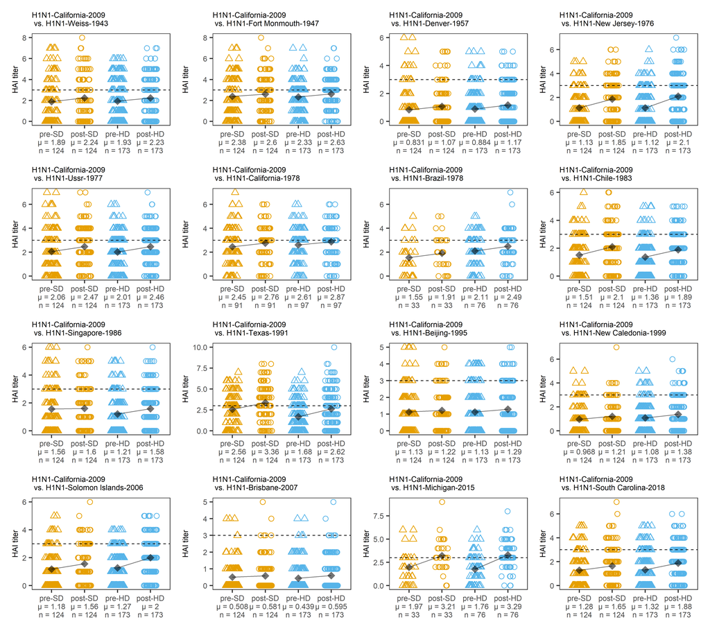

## Outcome definition

Investigate 4 antibody titer (HAI) outcomes:

- **Titer increase** following vaccination
- **Seroconversion**, defined as pre-vaccination HAI titer <1:10 (LOD) and post-vaccination titer >= 1:40 OR a >=4-fold increase
- **Post-vaccination HAI titer**
- **Seroprotection**, defined as post-vaccination HAI >= 1:40

All HAI titer dilution values are converted (log-transformed) to a scale from 0 - N with Limit of Detection (LOD) = 0, lowest dilution (1:10) = 1, etc. up to highest dilution (1:20480) = 12.

## Analyses

- We implemented univariate, multivariate and propensity score matching models.
- Each model was fit in a Bayesian framework.
- Results show the difference in outcomes between HD and SD vaccine.

## Strain-specicfic responses, H1N1

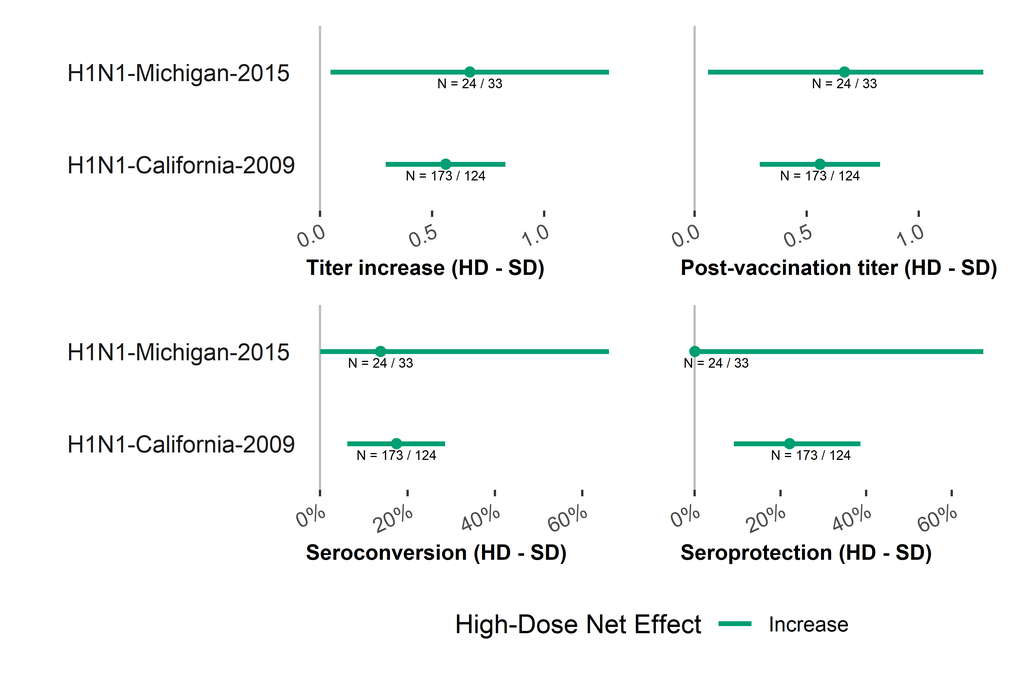

Median and 95% Credible Interval

Multivariate model with age, gender, race, pre-vaccination titer.

## Strain-specicfic responses, H3N2

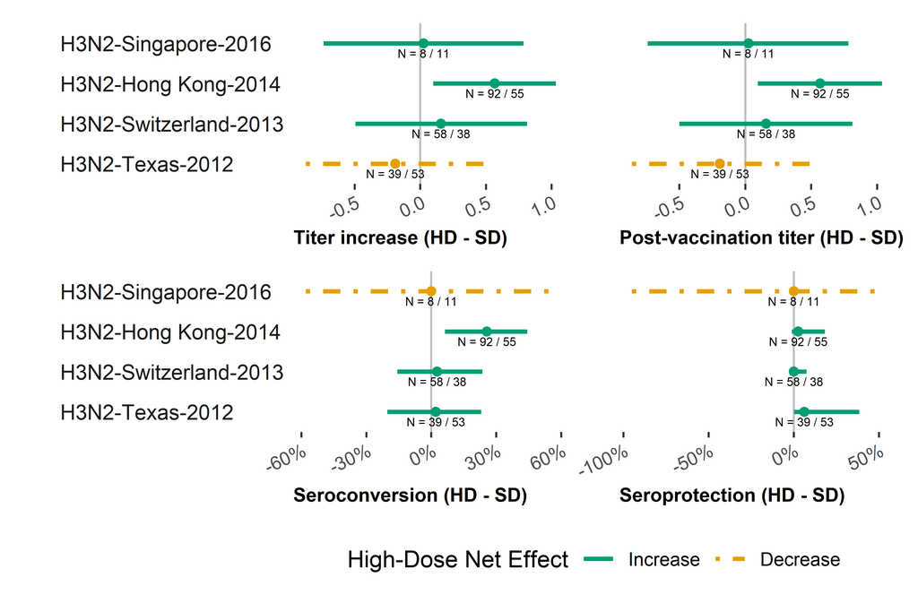

Median and 95% Credible Interval

## Strain-specicfic responses, B

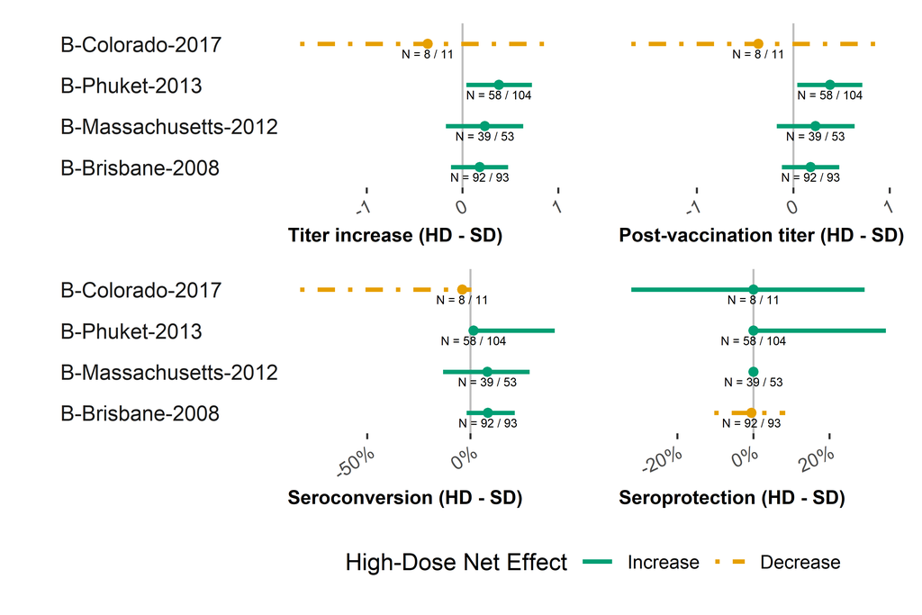

Median and 95% Credible Interval

## Heterologous responses, H1N1

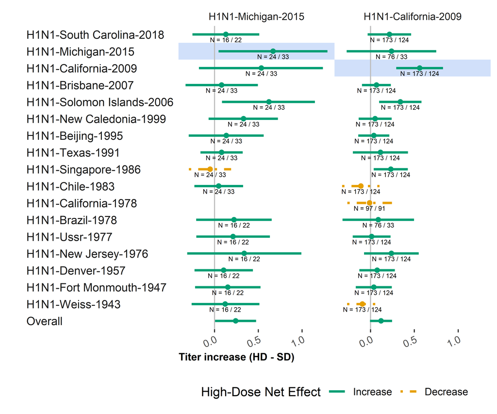

## Heterologous responses, H3N2

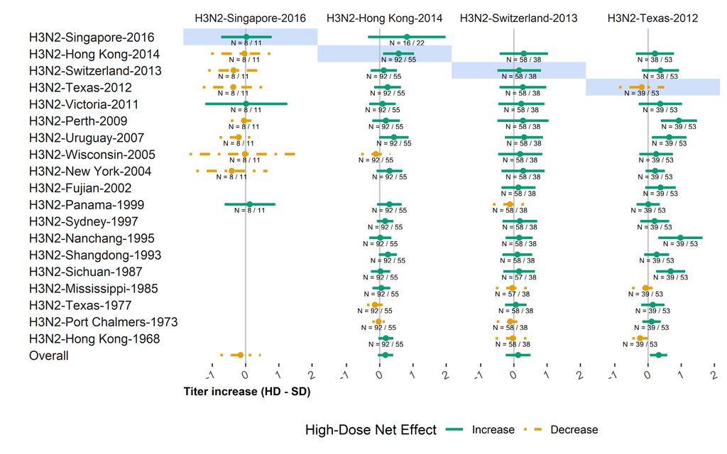

## Heterologous responses, B

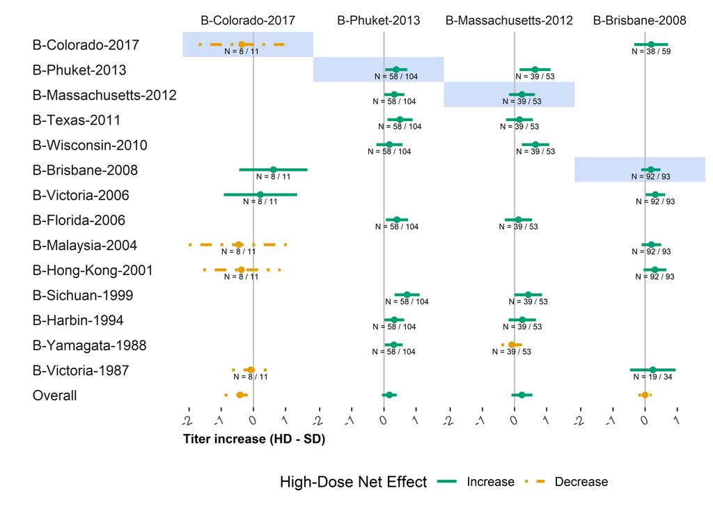

## Vaccine-specific analysis

Same 4 outcomes as before, but now computed per vaccine/season:

- For post-vaccination and increase in titer, the average response for all vaccine strains
- For Seroprotection/Seroconversion, the fraction of strains that elicit a response

## Vaccine-specific responses

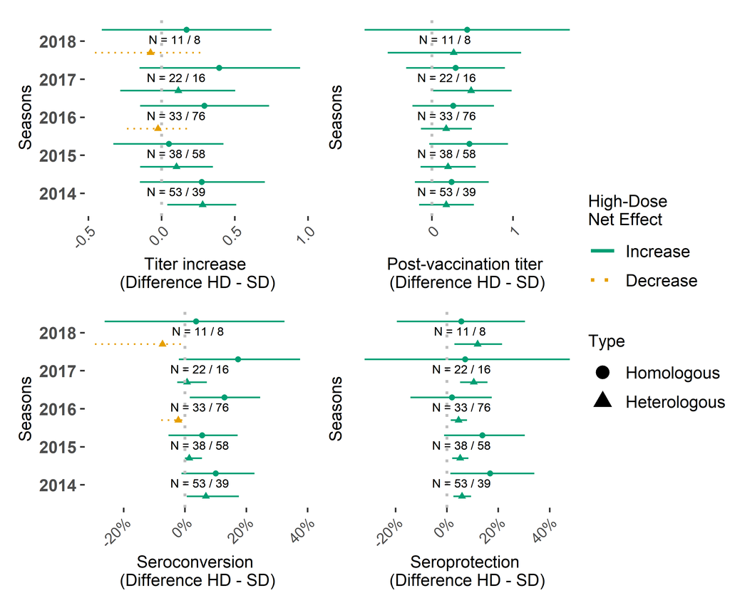

Median and 95% Credible Interval

## Summary

- For most vaccine components, HD produces a stronger response against the vaccine strain and heterologous strains. However this is not fully consistent.
- On a per-vaccine basis, HD is generally better at inducing a response.
- Further adjustment of dose and more broad use of HD vaccine should be considered.

## Thanks!

- Main work done by **Yang Ge**
- Other collaborators and contributors: Ye Shen, Ted Ross, Amanda Skarlupka, Zane Billings, Justin Bahl, Michael Carlock, Paul Thomas
- Funding: NIH/CIVIC (of course)
- Slides: https://www.andreashandel.com/talk/
- Contact: https://www.andreashandel.com/, @andreashandel